# ClassificationEnsembles-vignette

Welcome to ClassificationEnsembles! The goal of ClassificationEnsembles is to automatically conduct a thorough analysis of classification data. The user only needs to provide the data, answer a few questions, and the package does all the rest for you!.

The function will automatically work with any number of levels. In this example the data has three levels. Note that the function will automatically figure out the three levels, and build the models from there.

# Installation

You can install the development version of ClassificationEnsembles like so:

```
devtools::install_github("InfiniteCuriosity/ClassificationEnsembles")
```

# Example

```
Classification(data = ISLR::Carseats,
               colnum = 7,
               numresamples = 25,
               predict_on_new_data = "N",
               save_all_plots = "N",
               how_to_handle_strings = 1,
               stratified_random_column = 0,
               remove_VIF_above <- 5.00,
               set_seed = "N",
               save_all_trained_models = "N",
               scale_all_numeric_predictors_in_data = "N",
               use_parallel = "N",
               train_amount = 0.50,
               test_amount = 0.25,
               validation_amount = 0.25)
```

This is the head of the data set. We will be modeling the ShelveLoc column:

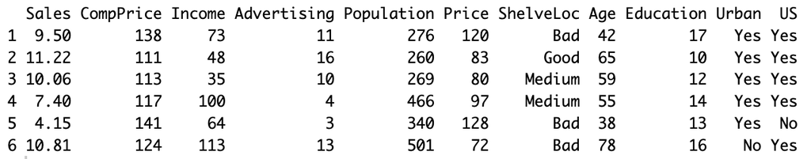

Head of carseats data set, the example will model the 7th column, ShelveLoc

Bagged Random Forest

Bagging

C50

Linear

Naive Bayes

Partial Least Squares

Penalized Discriminant Analysis

Random Forest

Ranger

RPart

Support Vector Machines

Trees

Ensemble Bagged Cart

Ensemble Bagged Random Forest

Ensemble C50

Ensemble Naive Bayes

Ensemble Random Forest

Ensemble Ranger

Ensemble Support Vector Machines

Ensemble Trees

ClassificationEnsembles automatically makes 25 plots. Here are a few of them:

Accuracy by model and resample

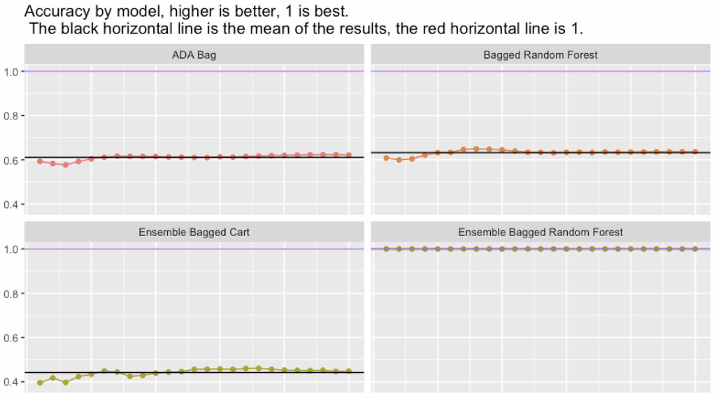

Closeup of accuracy by model

Accuracy including train and holdout

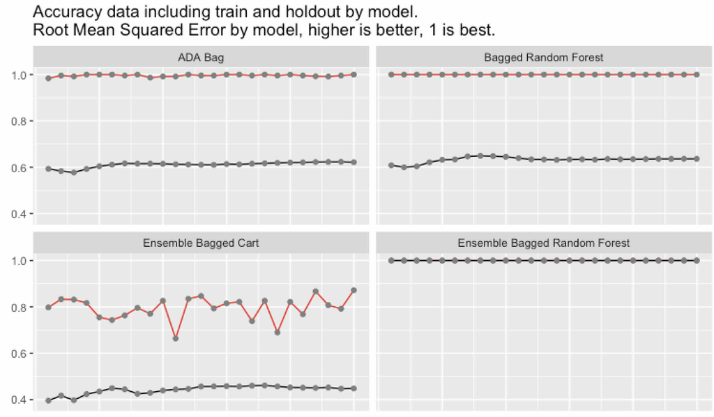

Closeup of accuracy by train and holdout

Note that Ensemble Bagged Random Forest had 100% accuracy on the holdout data, 25 times in a row.

Boxplots of the numeric data

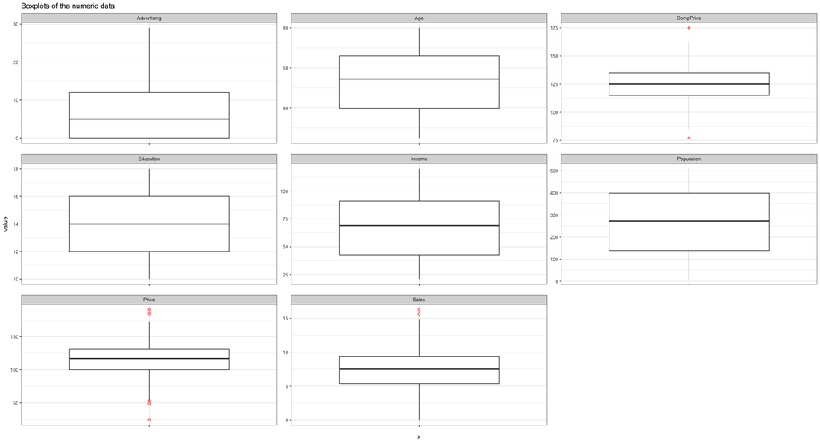

**Boxplots of the numeric data**

Correlation of the numeric data as numbers and colors

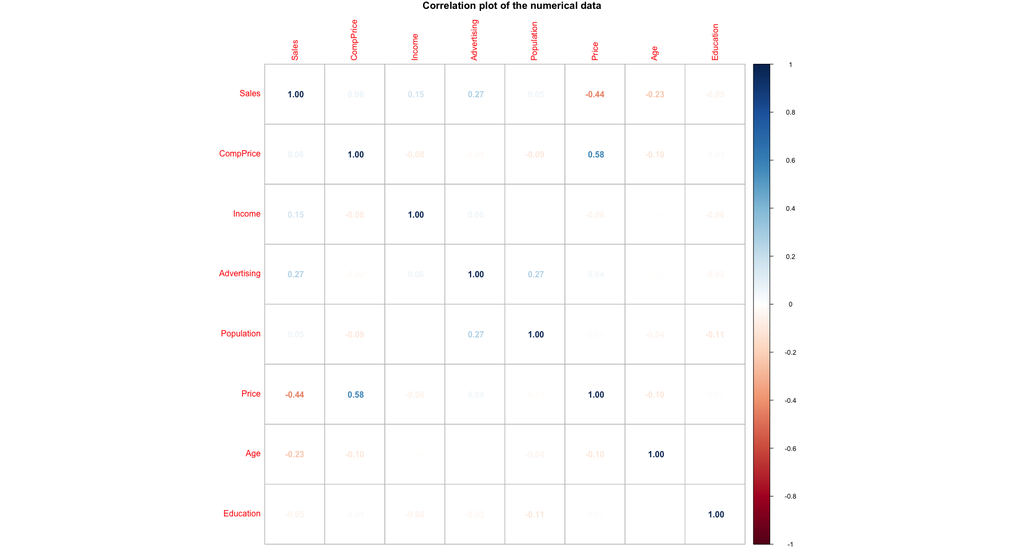

Correlation of the numeric data as numbers and colors

Duration barchart

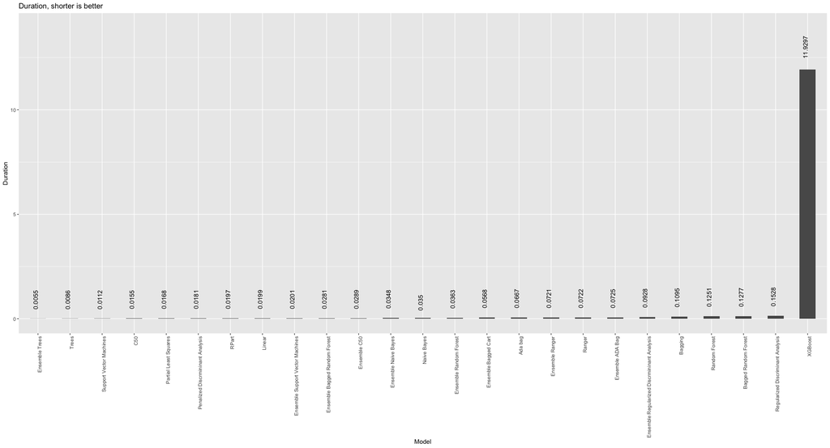

Duration barchart. The large bar at the end is XGBoost.

Histograms of the numeric columns

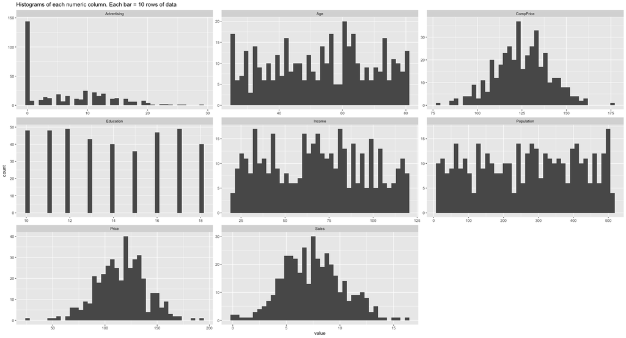

Histograms of the numeric columns

Model accuracy barchart

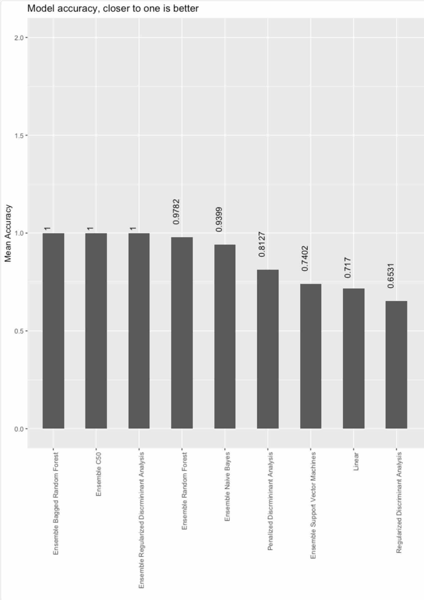

Closeup of accuracy barchart

Over or underfitting barchart

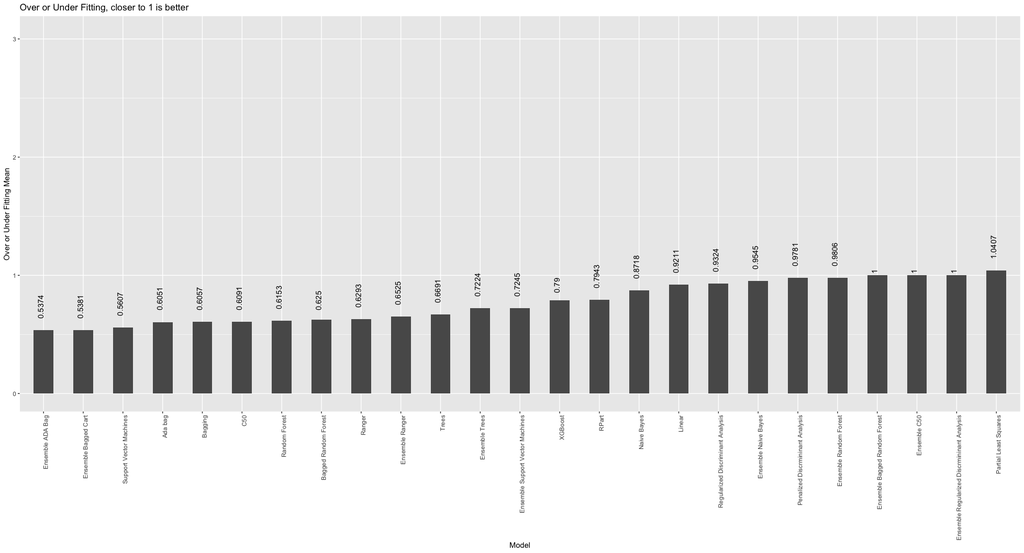

Over or underfitting barchart

Target vs each feature

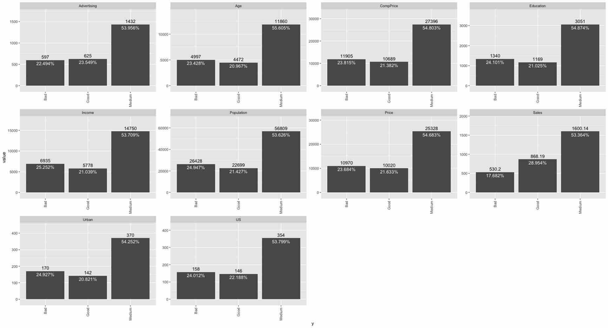

Target vs each feature

**Summary report example:**

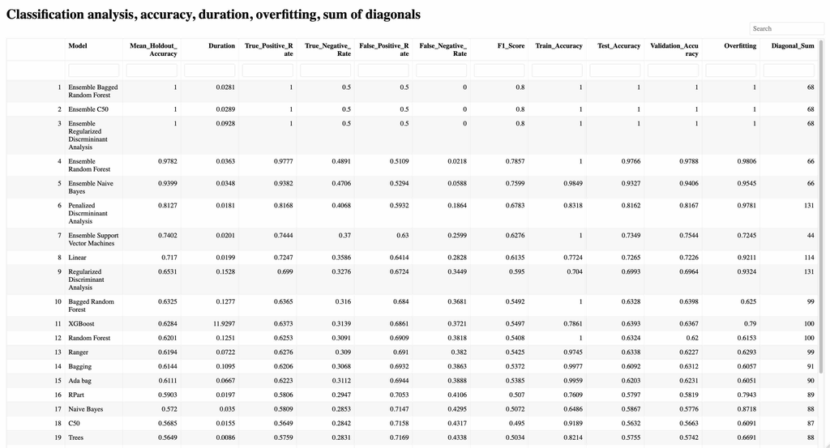

Summary report

The summary report provides the following for each classification model:

Model name

Holdout accuracy (note the best three models in this example are all ensembles)

Duration

True Positive Rate

True Negative Rate

False Positive Rate

False Negative Rate

F1 Score

Train Accuracy

Test Accuracy

Validation Accuracy

Overfitting

Diagonal Sum

**Tables provided:**

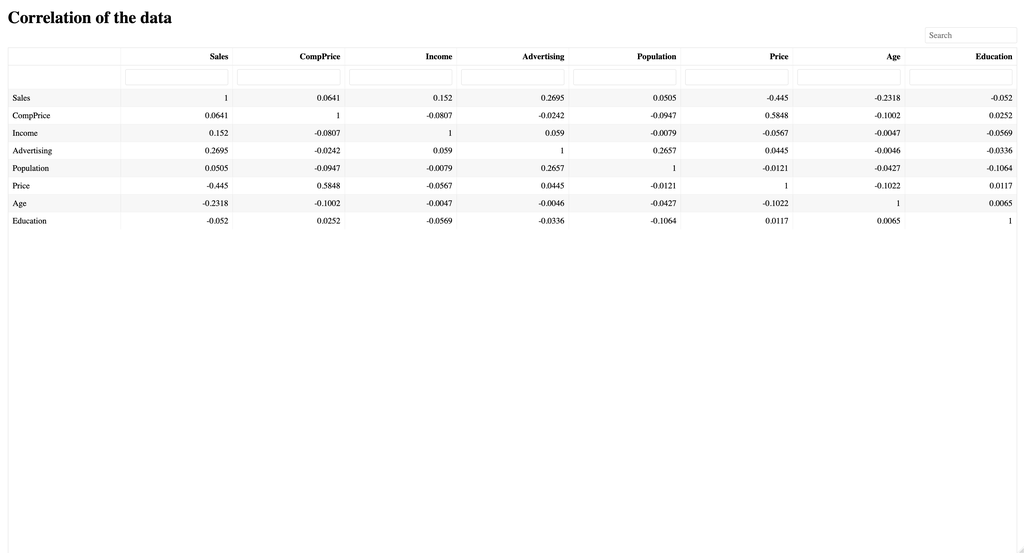

Correlation of the numeric data

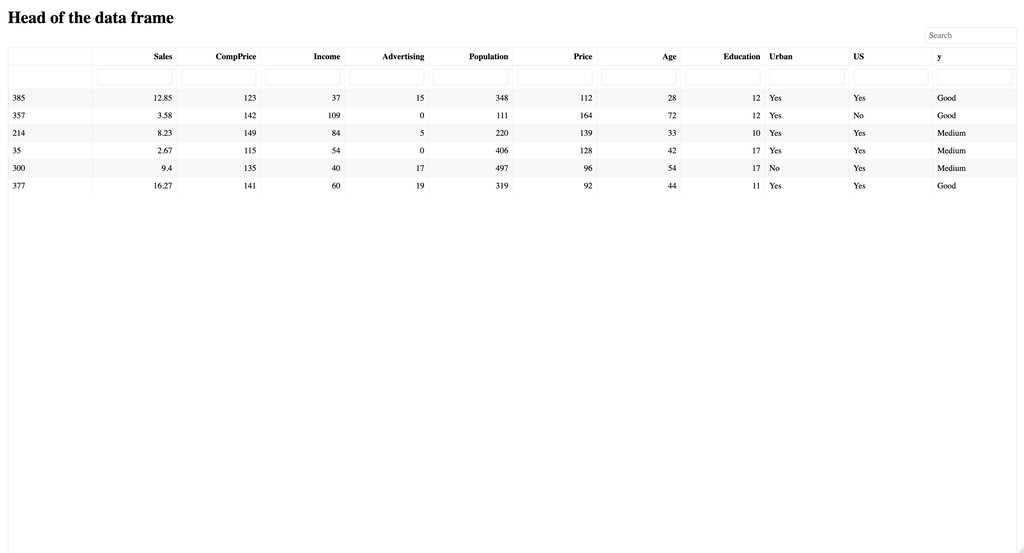

Head of the data frame:

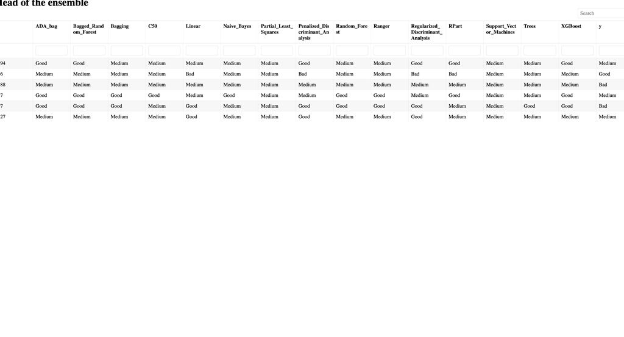

Head of the ensemble

**Summary tables for all models (top three shown in the graphic)**

The package also provides summary tables for all models. Here are the summary tables for the models with the highest accuracy:

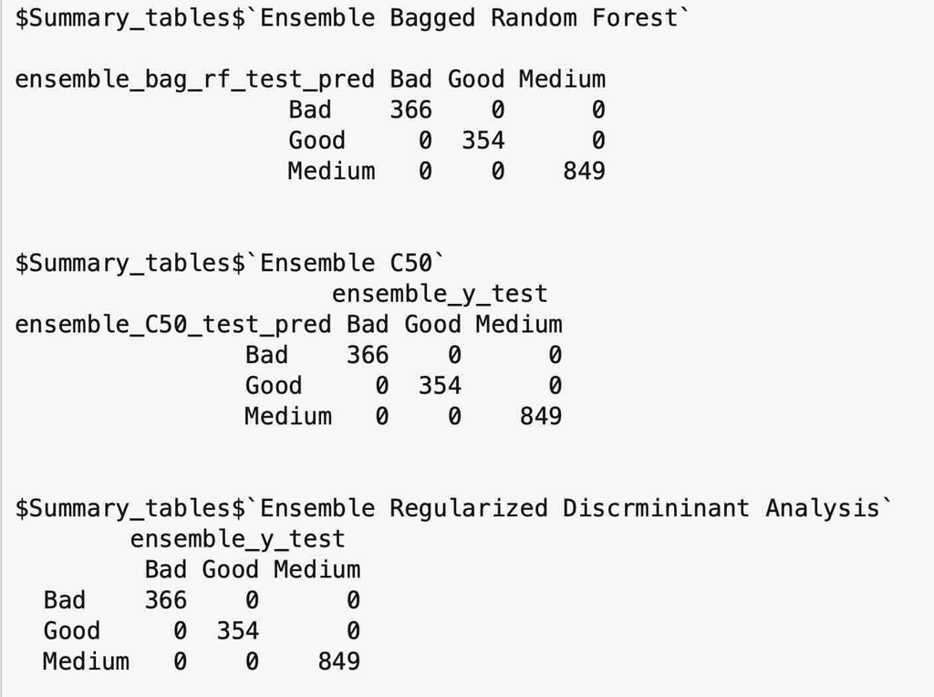

closeup of best summary tables

# Grand summary

The package also automatically provided 25 plots, five tables, a summary report, and summary tables all the models.